# Chapter 6

Nicolas May

1/5/2019

Load useful libraries.

```r
library(DBI)
library(odbc)
library(RPostgres)
```

# Chapter Sections

Connect to the *dvdrental* database.

```r
con_dvdrental <- dbConnect(odbc::odbc(), "PostgreSQL AWS dvdrental",
                           bigint = "numeric")
```

## Group Data with the GROUP BY Clause

An example using the `GROUP BY` clause:

```
SELECT customer_id, SUM(amount)
  FROM payment
  GROUP BY customer_id;
```

```sql
SELECT customer_id, SUM(amount)
  FROM payment
  GROUP BY customer_id
  ORDER BY SUM(amount) DESC;
```

Displaying records 1 - 10

| customer_id | sum |
| --- | --- |
| 148 | 211.55 |
| 526 | 208.58 |
| 178 | 194.61 |
| 137 | 191.62 |
| 144 | 189.60 |
| 459 | 183.63 |
| 181 | 167.67 |
| 410 | 167.62 |
| 236 | 166.61 |
| 403 | 162.67 |

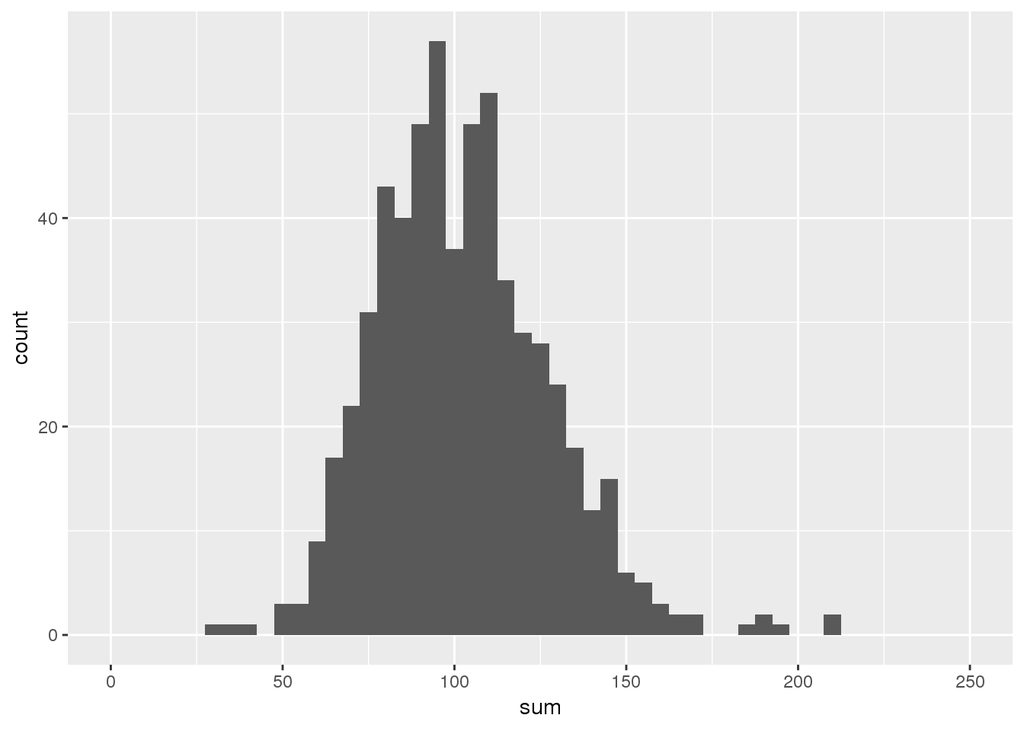

```r
customer_sums <-
  dbGetQuery(con_dvdrental,
             "SELECT customer_id, SUM(amount)
                FROM payment
                GROUP BY customer_id
                ORDER BY sum DESC;")
library(ggplot2)
ggplot(customer_sums, aes(x = sum)) +
  geom_histogram(binwidth = 5, na.rm = TRUE) +
  scale_x_continuous(limits = c(0L, 250L))
```

```r
dbGetQuery(con_dvdrental,
           "SELECT AVG(sub.sum)
              FROM (
                SELECT customer_id, SUM(amount) as sum
                  FROM payment
                  GROUP BY customer_id
              ) sub;")
```

```
##        avg
## 1 102.3573
```

```sql
SELECT AVG(sub.sum)
  FROM (
    SELECT customer_id, SUM(amount) as sum
      FROM payment
      GROUP BY customer_id
  ) sub;
```

1 records

| avg |
| --- |
| 102.357328881469 |

### Exercise

#### Task 1

Write a query that returns the number of films by rating.

```sql
SELECT rating, COUNT(*)
  FROM film
  GROUP BY rating
  ORDER BY rating;
```

5 records

| rating | count |
| --- | --- |
| G | 178 |
| PG | 194 |
| PG-13 | 223 |
| R | 195 |
| NC-17 | 210 |

## The HAVING Clause

An example using the `HAVING` filter:

```
SELECT customer_id, SUM(amount)
  FROM payment
  GROUP BY customer_id
  HAVING SUM(amount) > 200;
```

`HAVING` vs. `WHERE` – `WHERE` is used to filter rows *BEFORE* a `GROUP BY` clause, whereas `HAVING` is used to filter rows *AFTER* a `GROUP BY` clause.

An example with both `WHERE` and `HAVING`:

```
SELECT customer_id, SUM(amount)
  FROM payment
  WHERE customer_id != 10
  GROUP BY customer_id
  HAVING SUM(amount) > 200;
```

```sql
SELECT customer_id, SUM(amount)
  FROM payment
  GROUP BY customer_id
  HAVING SUM(amount) > 100
  ORDER BY SUM(AMOUNT) ASC;
```

Displaying records 1 - 10

| customer_id | sum |
| --- | --- |
| 135 | 100.72 |
| 251 | 100.75 |
| 219 | 100.75 |
| 572 | 100.76 |
| 517 | 100.76 |
| 486 | 100.77 |
| 405 | 101.70 |
| 593 | 101.76 |
| 100 | 101.77 |
| 466 | 101.78 |

```sql
SELECT customer_id, SUM(amount)
  FROM payment
  WHERE customer_id BETWEEN 25 AND 50
  GROUP BY customer_id
  HAVING SUM(amount) >= 125.00
  ORDER BY customer_id;
```

6 records

| customer_id | sum |
| --- | --- |
| 26 | 146.68 |
| 29 | 138.65 |
| 38 | 127.66 |
| 39 | 141.71 |
| 46 | 131.69 |
| 50 | 144.70 |

### Exercise

#### Task 1

Write a query that returns the number of films by rating with the rating ‘G’.

```sql
SELECT rating, COUNT(*)
  FROM film
  GROUP BY rating
  HAVING rating = 'G';
```

1 records

| rating | count |
| --- | --- |
| G | 178 |

Here’s a better exercise/task:

```sql
SELECT rating, COUNT(*)
  FROM film
  WHERE length > 150
  GROUP BY rating
  HAVING rating IN ('G', 'PG');
```

2 records

| rating | count |
| --- | --- |
| G | 40 |
| PG | 39 |

## PostgreSQL Aliases and the LIMIT Clause

Aliases with `AS`:

```sql
SELECT first_name AS f_name
  FROM customer
  WHERE first_name LIKE 'Ad%';
```

2 records

| f_name |
| --- |
| Adam |
| Adrian |

Limiting results returned with `LIMIT`:

```sql
SELECT *
  FROM customer
  ORDER BY customer_id DESC
  LIMIT 5;
```

5 records

| customer_id | store_id | first_name | last_name | email | address_id | activebool | create_date | last_update | active |
| --- | --- | --- | --- | --- | --- | --- | --- | --- | --- |
| 599 | 2 | Austin | Cintron | austin.cintron@sakilacustomer.org | 605 | 1 | 2006-02-14 | 2013-05-26 14:49:45 | 1 |
| 598 | 1 | Wade | Delvalle | wade.delvalle@sakilacustomer.org | 604 | 1 | 2006-02-14 | 2013-05-26 14:49:45 | 1 |
| 597 | 1 | Freddie | Duggan | freddie.duggan@sakilacustomer.org | 603 | 1 | 2006-02-14 | 2013-05-26 14:49:45 | 1 |
| 596 | 1 | Enrique | Forsythe | enrique.forsythe@sakilacustomer.org | 602 | 1 | 2006-02-14 | 2013-05-26 14:49:45 | 1 |
| 595 | 1 | Terrence | Gunderson | terrence.gunderson@sakilacustomer.org | 601 | 1 | 2006-02-14 | 2013-05-26 14:49:45 | 1 |

Using `OFFSET` with `ORDER BY`:

```sql
SELECT *
  FROM customer
  ORDER BY customer_id ASC
  LIMIT 5
  OFFSET 3;
```

5 records

| customer_id | store_id | first_name | last_name | email | address_id | activebool | create_date | last_update | active |
| --- | --- | --- | --- | --- | --- | --- | --- | --- | --- |
| 4 | 2 | Barbara | Jones | barbara.jones@sakilacustomer.org | 8 | 1 | 2006-02-14 | 2013-05-26 14:49:45 | 1 |
| 5 | 1 | Elizabeth | Brown | elizabeth.brown@sakilacustomer.org | 9 | 1 | 2006-02-14 | 2013-05-26 14:49:45 | 1 |
| 6 | 2 | Jennifer | Davis | jennifer.davis@sakilacustomer.org | 10 | 1 | 2006-02-14 | 2013-05-26 14:49:45 | 1 |
| 7 | 1 | Maria | Miller | maria.miller@sakilacustomer.org | 11 | 1 | 2006-02-14 | 2013-05-26 14:49:45 | 1 |
| 8 | 2 | Susan | Wilson | susan.wilson@sakilacustomer.org | 12 | 1 | 2006-02-14 | 2013-05-26 14:49:45 | 1 |

```sql
SELECT customer_id AS id, first_name AS fn, last_name as ln
  FROM customer
  ORDER BY customer_id
  LIMIT 7 OFFSET 13;
```

7 records

| id | fn | ln |
| --- | --- | --- |
| 14 | Betty | White |
| 15 | Helen | Harris |
| 16 | Sandra | Martin |
| 17 | Donna | Thompson |
| 18 | Carol | Garcia |
| 19 | Ruth | Martinez |
| 20 | Sharon | Robinson |

## Exploring Inner Joins

Example of an inner join between *customer* and *payment* tables.

```
SELECT
    first_name, last_name, -- customer table
    amount                 -- payment table
  FROM
    customer
  INNER JOIN
    payment
    ON customer.cusomter_id = payment.customer_id;
```

```sql
SELECT
    first_name, last_name, -- customer table
    amount                 -- payment table
  FROM
    customer
  INNER JOIN
    payment
    ON customer.customer_id = payment.customer_id;
```

Displaying records 1 - 10

| first_name | last_name | amount |
| --- | --- | --- |
| Peter | Menard | 7.99 |
| Peter | Menard | 1.99 |
| Peter | Menard | 7.99 |
| Peter | Menard | 2.99 |
| Peter | Menard | 7.99 |
| Peter | Menard | 5.99 |
| Harold | Martino | 5.99 |
| Harold | Martino | 5.99 |
| Harold | Martino | 2.99 |
| Douglas | Graf | 4.99 |

### Exercise

#### Task 1

Write a query that selects the first_name, last_name, and address columns from the “customer” and “address” tables using an `INNER JOIN`.

```r
dbListFields(con_dvdrental, "customer")
```

```
##  [1] "customer_id" "store_id"    "first_name"  "last_name"   "email"
##  [6] "address_id"  "activebool"  "create_date" "last_update" "active"
```

```r
dbListFields(con_dvdrental, "address")
```

```
## [1] "address_id"  "address"     "address2"    "district"    "city_id"
## [6] "postal_code" "phone"       "last_update"
```

```sql
SELECT
    first_name, last_name, -- customer
    address                -- address
  FROM
    customer
  INNER JOIN
    address
    ON
      customer.address_id = address.address_id;
```

Displaying records 1 - 10

| first_name | last_name | address |
| --- | --- | --- |
| Jared | Ely | 1003 Qinhuangdao Street |
| Mary | Smith | 1913 Hanoi Way |
| Patricia | Johnson | 1121 Loja Avenue |
| Linda | Williams | 692 Joliet Street |
| Barbara | Jones | 1566 Inegl Manor |
| Elizabeth | Brown | 53 Idfu Parkway |
| Jennifer | Davis | 1795 Santiago de Compostela Way |
| Maria | Miller | 900 Santiago de Compostela Parkway |
| Susan | Wilson | 478 Joliet Way |
| Margaret | Moore | 613 Korolev Drive |

## Exploring Outer Joins

```r
dbListTables(con_dvdrental)
```

```
##  [1] "actor"                      "actor_info"
##  [3] "address"                    "category"
##  [5] "city"                       "country"
##  [7] "customer"                   "customer_list"
##  [9] "film"                       "film_actor"
## [11] "film_category"              "film_list"
## [13] "inventory"                  "language"
## [15] "nicer_but_slower_film_list" "payment"
## [17] "rental"                     "sales_by_film_category"
## [19] "sales_by_store"             "staff"
## [21] "staff_list"                 "store"
```

```r
dbListFields(con_dvdrental, "film")
```

```
##  [1] "film_id"          "title"            "description"
##  [4] "release_year"     "language_id"      "rental_duration"
##  [7] "rental_rate"      "length"           "replacement_cost"
## [10] "rating"           "last_update"      "special_features"
## [13] "fulltext"
```

```r
dbListFields(con_dvdrental, "inventory")
```

```
## [1] "inventory_id" "film_id"      "store_id"     "last_update"
```

```sql
SELECT *
  FROM inventory
  LIMIT 20;
```

Displaying records 1 - 10

| inventory_id | film_id | store_id | last_update |
| --- | --- | --- | --- |
| 1 | 1 | 1 | 2006-02-15 10:09:17 |
| 2 | 1 | 1 | 2006-02-15 10:09:17 |
| 3 | 1 | 1 | 2006-02-15 10:09:17 |
| 4 | 1 | 1 | 2006-02-15 10:09:17 |
| 5 | 1 | 2 | 2006-02-15 10:09:17 |
| 6 | 1 | 2 | 2006-02-15 10:09:17 |
| 7 | 1 | 2 | 2006-02-15 10:09:17 |
| 8 | 1 | 2 | 2006-02-15 10:09:17 |
| 9 | 2 | 2 | 2006-02-15 10:09:17 |
| 10 | 2 | 2 | 2006-02-15 10:09:17 |

### LEFT OUTER JOIN

```sql
SELECT
  film.film_id, film.title, -- film
  inventory.inventory_id    -- inventory
FROM
  film
LEFT OUTER JOIN
  inventory
  ON
    film.film_id = inventory.film_id
  ORDER BY film_id, inventory_id;
```

Displaying records 1 - 10

| film_id | title | inventory_id |
| --- | --- | --- |
| 1 | Academy Dinosaur | 1 |
| 1 | Academy Dinosaur | 2 |
| 1 | Academy Dinosaur | 3 |
| 1 | Academy Dinosaur | 4 |
| 1 | Academy Dinosaur | 5 |
| 1 | Academy Dinosaur | 6 |
| 1 | Academy Dinosaur | 7 |
| 1 | Academy Dinosaur | 8 |
| 2 | Ace Goldfinger | 9 |
| 2 | Ace Goldfinger | 10 |

```sql
SELECT
    film.film_id, film.title, -- film
    inventory.inventory_id    -- inventory
  FROM
    film
  LEFT OUTER JOIN
    inventory
    ON film.film_id = inventory.film_id
  WHERE
    inventory.film_id IS NULL
  ORDER BY
    film_id, inventory_id;
```

Displaying records 1 - 10

| film_id | title | inventory_id |
| --- | --- | --- |
| 14 | Alice Fantasia | NA |
| 33 | Apollo Teen | NA |
| 36 | Argonauts Town | NA |
| 38 | Ark Ridgemont | NA |
| 41 | Arsenic Independence | NA |
| 87 | Boondock Ballroom | NA |
| 108 | Butch Panther | NA |
| 128 | Catch Amistad | NA |
| 144 | Chinatown Gladiator | NA |
| 148 | Chocolate Duck | NA |

## Assignment

```r
dbListTables(con_dvdrental)
```

```
##  [1] "actor"                      "actor_info"
##  [3] "address"                    "category"
##  [5] "city"                       "country"
##  [7] "customer"                   "customer_list"
##  [9] "film"                       "film_actor"
## [11] "film_category"              "film_list"
## [13] "inventory"                  "language"
## [15] "nicer_but_slower_film_list" "payment"
## [17] "rental"                     "sales_by_film_category"
## [19] "sales_by_store"             "staff"
## [21] "staff_list"                 "store"
```

### Problem 1

It’s another day at the DVD rental store, and your manager asked for help find the sum of all payments transacted by staff ID.

```r
dbListFields(con_dvdrental, "payment")
```

```
## [1] "payment_id"   "customer_id"  "staff_id"     "rental_id"
## [5] "amount"       "payment_date"
```

```sql
SELECT staff_id, SUM(amount)
  FROM payment
  GROUP BY staff_id
  ORDER BY SUM(amount) DESC;
```

2 records

| staff_id | sum |
| --- | --- |
| 2 | 31059.92 |
| 1 | 30252.12 |

### Problem 2

Corporate headquarters has decided to debut a loyalty program for customers who frequently visit the store. Before the program launches, your manager has decided to give customers with more than 40 transactions early access to the program. Write a query the returns the customer IDs having more than 40 transactions.

```sql
SELECT customer_id, COUNT(*)
  FROM payment
  GROUP BY customer_id
  HAVING COUNT(*) > 40
  ORDER BY COUNT(*) DESC;
```

2 records

| customer_id | count |
| --- | --- |
| 148 | 45 |
| 526 | 42 |

### Problem 3

It’s the next day at the DVD rental store, and a customer approaches you for a favor. They want to mail a “Thank You” card to the manager of DVD rental store #2, but they don’t have the address. Write a query that returns the address of store_id 2.

```r
dbListFields(con_dvdrental, "store")
```

```
## [1] "store_id"         "manager_staff_id" "address_id"
## [4] "last_update"
```

```r
dbListFields(con_dvdrental, "address")
```

```
## [1] "address_id"  "address"     "address2"    "district"    "city_id"
## [6] "postal_code" "phone"       "last_update"
```

```sql
SELECT
    store.store_id,
    address.address,
    address.city_id,
    address.postal_code
  FROM store
  INNER JOIN address
    ON store.address_id = address.address_id
  WHERE store.store_id = 2;
```

1 records

| store_id | address | city_id | postal_code |
| --- | --- | --- | --- |
| 2 | 28 MySQL Boulevard | 576 |  |

### Problem 4

Later in the day your manager asks you for help locating address that do not have customers assigned to them. Write a query that returns all the columns for the address table that do not have matching customer records.

```r
dbListFields(con_dvdrental, "customer")
```

```
##  [1] "customer_id" "store_id"    "first_name"  "last_name"   "email"
##  [6] "address_id"  "activebool"  "create_date" "last_update" "active"
```

```r
dbListFields(con_dvdrental, "address")
```

```
## [1] "address_id"  "address"     "address2"    "district"    "city_id"
## [6] "postal_code" "phone"       "last_update"
```

```sql
SELECT
    address.address_id,
    address.address,
    customer.customer_id,
    customer.first_name,
    customer.last_name
  FROM address
  LEFT OUTER JOIN customer
    ON address.address_id = customer.address_id
  WHERE customer.address_id IS NULL;
```

4 records

| address_id | address | customer_id | first_name | last_name |
| --- | --- | --- | --- | --- |
| 1 | 47 MySakila Drive | NA | NA | NA |
| 2 | 28 MySQL Boulevard | NA | NA | NA |
| 3 | 23 Workhaven Lane | NA | NA | NA |
| 4 | 1411 Lillydale Drive | NA | NA | NA |

Disconnect from the *dvdrental* database.

```r
dbDisconnect(con_dvdrental)
```

[output not shown]